# Learning the BASiCS: a Bayesian approach to single-cell RNA-seq data analysis

Catalina Vallejos and Aaron Lun

2016-10-13

# Setting up the R session

Open a new session of R Studio

- To clean the existig R environment use

```r
rm(list = ls())
```

- Install required libraries from BioConductor

```r
source("http://bioconductor.org/biocLite.R")
biocLite("BiocGenerics")
biocLite("scran")
biocLite("scater")
```

- Install BASiCS from Github

```r
library(devtools)
install_github('catavallejos/BASiCS')
```

Load the libraries that will be used througout the analysis

- To perform the analysis

```r
library(scran)
library(scater)
library(BASiCS)
```

- For fast pre-processing of large datasets

```r
# install.packages("data.table")
library(data.table)
```

# Example dataset

To illustrate BASiCS, we analyse the mouse embryonic stem cell (ESC) dataset described in Islam et al (2014). In these data, expression counts are recorded in terms of Unique Molecular Identifiers (UMI), removing amplification biases.

Let `data.path` be the directory where the data is stored, e.g.

```r
core.path = "~/Documents/Github/TutorialBASiCS/"
data.path = file.path(core.path, "Data")
```

The following files must be stored in the `data.path` directory:

- **Expression counts**: `GSE46980_CombinedMoleculeCounts.tab`
- **Quality control information**: `187_3lanes_CA.txt` (provided by Sten Linnarsson).
- **Input molecules of spike-in genes**: `SilverBulletCTRLConc.txt` (provided by Sten Linnarsson).

These files are provided within the materials of this tutorial.

## Loading the data

To read the matrix of expression counts (excluding metadata) use:

```r
Counts <- read.table(file.path(data.path,
                            "GSE46980_CombinedMoleculeCounts.tab"),
                      skip = 7, sep = "\t",
                      colClasses = c(rep("NULL", 7),
                                     rep("numeric", 96)))
dim(Counts)
```

This dataset contains 25914 genes (one at each row) and 96 cells (one at each column).

## Metadata (gene names)

Gene names are given by

```r
Genes <- read.table(file.path(data.path,
                           "GSE46980_CombinedMoleculeCounts.tab"),
                           skip = 7, sep = "\t",
                           colClasses = c("character",
                                          rep("NULL", 102)))[,1]
rownames(Counts) <- Genes
```

## Metadata (cell identifiers)

Cell identifiers are given by

```r
Cells <- read.table(file.path(data.path,
                        "GSE46980_CombinedMoleculeCounts.tab"),
                        skip = 5, nrows = 1, header = F)[-1]
Cells <- as.vector(t(Cells))
colnames(Counts) <- Cells
```

## What does the data look like?

```r
head(Counts[, 1:10], n = 10)
```

```
##                A01 B01 C01 D01 E01 F01 G01 H01 A02 B02
## RNA_SPIKE_MC01   0   0   0   0   0   0   0   0   0   0
## RNA_SPIKE_MC02   0   7   2   8   4   1   3   0   0   1
## RNA_SPIKE_MC04   0   0   0   0   0   0   0   0   0   0
## RNA_SPIKE_MC07   0   0   0   0   0   0   0   0   0   0
## RNA_SPIKE_MC08   0   0   0   0   0   0   0   0   0   0
## RNA_SPIKE_MC09   0   0   0   0   0   0   0   0   0   0
## RNA_SPIKE_MC10   0   0   0   0   0   0   0   0   0   0
## RNA_SPIKE_MC14   4   2   3   5   1  10   2   1   3   1
## RNA_SPIKE_MC19   6   2   5   2   4   0   1   0   4   0
## RNA_SPIKE_MC20   6   4   1   1   2   0   0   3   0   1
```

## Filtering cells

We adopt the same quality control criterion as in Islam et al (2014).

```r
QC_Info <- read.table(file.path(data.path,
                             "187_3lanes_CA.txt"),
                   header = TRUE)
GoodCells <- QC_Info$Well[QC_Info$GoodCell==1]
```

We also discard 9 cells that are not ESCs (information provided by Sten Linnarsson)

```r
NotESC <- c("D02", "E02", "A06", "H07", "D08",
      "A09", "G10", "F12", "G12")
GoodCells <- GoodCells[!(GoodCells %in% NotESC)]
```

To remove cells that do not pass the inclusion criteria use

```r
CountsQC <- subset(Counts,
                select = Cells %in% GoodCells)
dim(CountsQC)
```

## Filtering genes

To compute the total number of counts (over all cells) per gene use

```r
TotCountsPerGene = rowSums(CountsQC)
sum(TotCountsPerGene == 0)
```

Here, we only include those genes with (on average) at least 1 count per cell (i.e. when total counts are at least equal to the number of analysed cells).

```r
GenesInclude = TotCountsPerGene >= 41
CountsQC = as.matrix(CountsQC[GenesInclude, ])
dim(CountsQC)
```

# Running BASiCS

## Building the BASiCS input dataset

As an input, BASiCS requires an object of class `BASiCS_Data`. To create this object, we need the following elements

- A matrix of expression counts, whose `rownames` contain the associated gene names
- A logical vector indicating whether or not each gene is a technical spike
- A `data.frame` whose first and second columns contain the gene names assigned to the spike-in genes and the associated input number of molecules, respectively.

First, we create a variable indicating whether or not a gene is a technical spike (for every gene)

```r
TechQC = grepl("SPIKE", rownames(CountsQC))
```

REMINDER: Gene names must be stored as `rownames(CountsQC)`

Secondly, we need the input number of spike-in molecules per cell. This is provided in `SilverBulletCTRLConc.txt`.

```r
SpikeInfo <- read.table(file.path(data.path,
                                "SilverBulletCTRLConc.txt"),
                      sep = "\t", header = TRUE,
                      colClasses = c(rep("NULL", 5),
                                     "character",
                                     rep("NULL", 3),
                                     "numeric"))
head(SpikeInfo, n = 4)
```

```
##                   Name molecules_in_each_chamber
## 1       RNA_SPIKE_MC28                 4042.8912
## 2 RNA_SPIKE_MJ-1000-67                  252.6807
## 3  RNA_SPIKE_MJ-500-35                 2021.4456
## 4       RNA_SPIKE_TagJ                  252.6807
```

NOTE: These values can be calculated using experimental information. For each spike-in gene $i$, we use \begin{equation*} \mu_{i} = C_i \times 10^{-18} \times (6.022 \times 10^{23}) \times (9 \times 10^{-3}) \times D \hspace{0.5cm} \mbox{where,} \end{equation*} \vspace{-0.1cm}

- $C_i$ is the concentration of the spike $i$ in the ERCC mix
- $10^{-18}$ is to convert att to mol
- $6.022 \times 10^{23}$ is the Avogadro number (mol $\rightarrow$ molecule)
- $9 \times 10^{-3}$ is the volume added into each chamber
- $D$ is a dilution factor

This file include spike-in genes that did not pass the inclusion criteria. To remove these use

```r
SpikeInfoQC <- SpikeInfo[SpikeInfo$Name %in% rownames(CountsQC)[TechQC],]
```

Finally, to create a `BASiCS_Data` object use

```r
Data = newBASiCS_Data(Counts = CountsQC,
                   Tech = TechQC,
                   SpikeInfo = SpikeInfoQC)
```

```
## An object of class BASiCS_Data
##  Dataset contains 7941 genes (7895 biological and 46 technical) and 41 cells.
##  Elements (slots): Counts, Tech, SpikeInput, GeneNames and BatchInfo.
##  The data contains 1 batch.
##
## NOTICE: BASiCS requires a pre-filtered dataset
##     - You must remove poor quality cells before creating the BASiCS data object
##     - We recommend to pre-filter very lowly expressed transcripts before creating the object.
##       Inclusion criteria may vary for each data. For example, remove transcripts
##           - with very low total counts across of all of the samples
##           - that are only expressed in a few cells
##             (by default genes expressed in only 1 cell are not accepted)
##           - with very low total counts across the samples where the transcript is expressed
##
##  BASiCS_Filter can be used for this purpose
```

## The BASiCS model

For each gene $i$ and cell $j$ the model implemented in BASiCS is \begin{equation*} \label{eqSCE:model2} X_{ij} | \mu_i, \phi_j, \nu_j, \rho_{ij} \sim \left\{ \begin{array}{ll} \mbox{Poisson}( \phi_j \nu_j \mu_i \rho_{ij}), & \hbox{if gene $i$ is biological;} \\ \mbox{Poisson}(\nu_j \mu_i), & \hbox{if gene $i$ is a technical spike, with} \end{array} \right. \end{equation*} \begin{equation*} \label{eqSCE:model2_1} \nu_j|s_j,\theta \sim \mbox{Gamma}(1/\theta,1/ (s_j \theta)) \hspace{1cm} \mbox{and} \hspace{1cm} \rho_{ij} | \delta_i \sim \mbox{Gamma} (1/\delta_i,1/\delta_i), \end{equation*}

- $\phi_j$ and $s_j$ are cell-specific normalising constants
- $\nu_j$ and $\theta$ capture technical noise
- $\mu_i$ is the overall expression rate of a gene $i$
- $\delta_i$ controls cell-to-cell biological variability of a gene $i$

## Running BASiCS

The `BASiCS_MCMC` function runs the MCMC sampler. It receives multiple arguments, however most of them are optional. There are 4 arguments that are required to run this function:

- `Data`: an object of class `BASiCS_Data`.
- `N`: Total number of iterations for the MCMC sampler.
- `Thin`: Thining period for the MCMC sampler.
- `Burn`: Burn-in period for the MCMC sampler.

For more information about the `BASiCS_MCMC` function use

```r
help("BASiCS_MCMC", package = "BASiCS")
```

For a short run of the model use

```r
MCMC_Output <- BASiCS_MCMC(Data,
                        N = 20,
                        Thin = 2,
                        Burn = 4)
```

Optional parameters

`StoreChains`:

If `TRUE`, the slots of the generated `BASiCS_Chain` object are stored in separate `.txt` files (one iteration at each row) using `RunName` argument to index file names (default: `StoreChains = FALSE`)

\vspace{0.5cm}

`StoreDir`:

Directory where output files are stored (default: `StoreDir = getwd()`)

\vspace{0.5cm}

Once the MCMC algorithm has run, we need to assess whether the chains to their stationary distribution.

- Combination of visual inspections and test-based diagnostics
- The `R` library `coda` includes several convergence diagnostics

More details in separate slides …

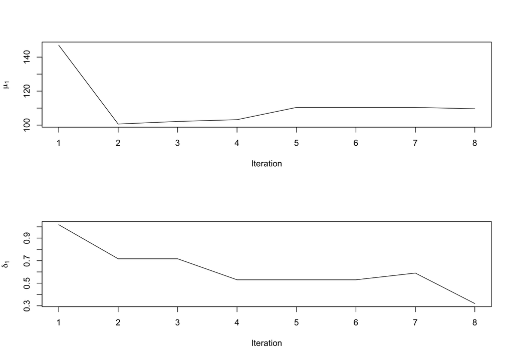

```r
par(mfrow = c(2,1))
plot(MCMC_Output, Param = "mu", Gene = 1)
plot(MCMC_Output, Param = "delta", Gene = 1)
```

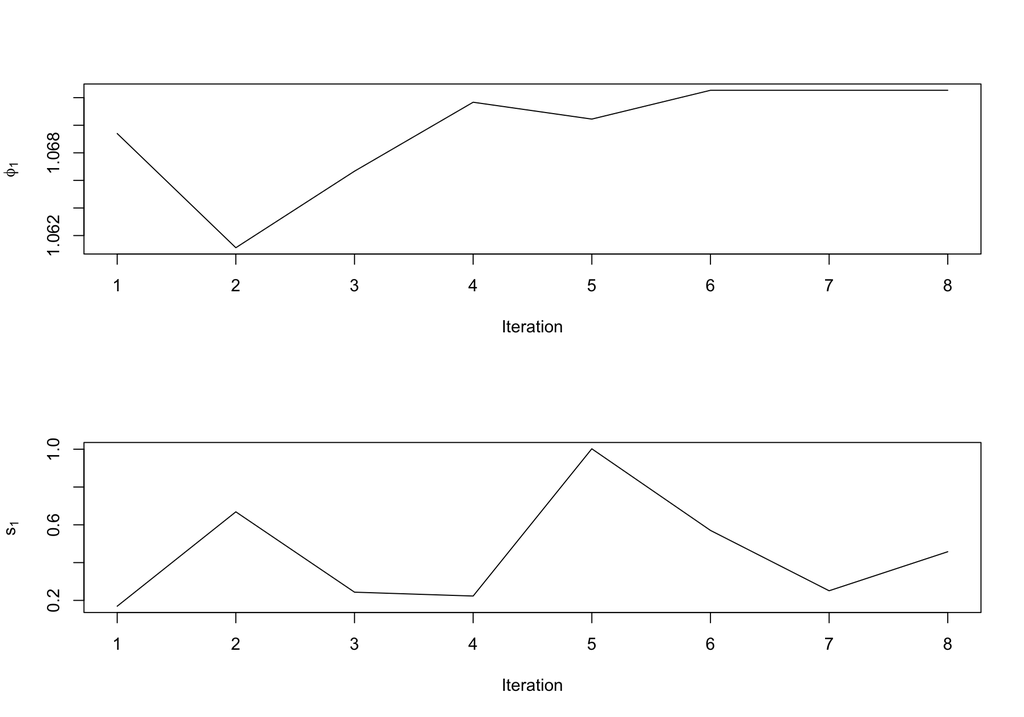

```r
par(mfrow = c(2,1))
plot(MCMC_Output, Param = "phi", Cell = 1)
plot(MCMC_Output, Param = "s", Cell = 1)
```

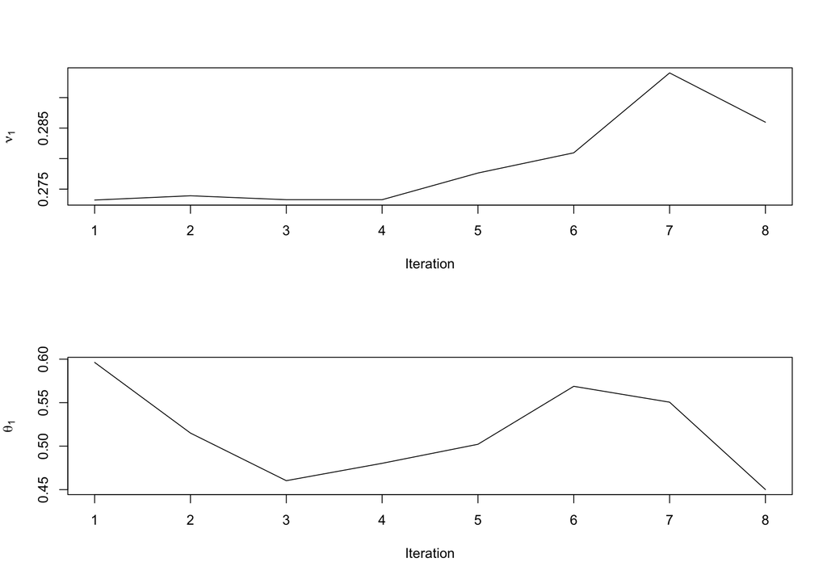

```r
par(mfrow = c(2,1))
plot(MCMC_Output, Param = "nu", Cell = 1)
plot(MCMC_Output, Param = "theta")
```

Clearly, `N = 20` iterations is not enough. Before continuing, we load the provided pre-computed MCMC chains `N = 20000` (~39 min run time on a Macbook). These were obtained using the following command

## Pre-run chains

```r
MCMC_Output <- BASiCS_MCMC(Data,
                           N = 20000,
                           Thin = 10,
                           Burn = 10000,
                           StoreChains = TRUE,
                           StoreDir = chains.path,
                           RunName = "Tutorial2016")
```

```r
ChainMu=fread(file.path(chains.path,"chain_mu_Tutorial2016.txt"), header = TRUE)
ChainDelta=fread(file.path(chains.path,"chain_delta_Tutorial2016.txt"), header = TRUE)
ChainPhi=fread(file.path(chains.path,"chain_phi_Tutorial2016.txt"), header = TRUE)
ChainS=fread(file.path(chains.path,"chain_s_Tutorial2016.txt"), header = TRUE)
ChainNu=fread(file.path(chains.path,"chain_nu_Tutorial2016.txt"), header = TRUE)
ChainTheta=fread(file.path(chains.path,"chain_theta_Tutorial2016.txt"), header = TRUE)

MCMC_Output = newBASiCS_Chain(mu = as.matrix(ChainMu),
                           delta = as.matrix(ChainDelta),
                           phi = as.matrix(ChainPhi),
                           s = as.matrix(ChainS),
                           nu = as.matrix(ChainNu),
                           theta = as.matrix(ChainTheta))
```

```
## An object of class BASiCS_Chain
##  1000 MCMC samples.
##  Dataset contains 7895 biological genes and 41 cells (1 batch).
##  Elements (slots): mu, delta, phi, s, nu and theta.
```

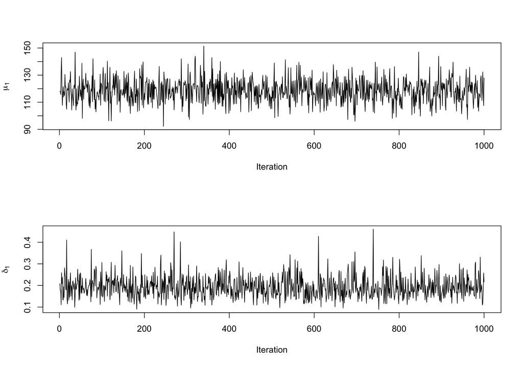

```r
par(mfrow = c(2,1))
plot(MCMC_Output, Param = "mu", Gene = 1)
plot(MCMC_Output, Param = "delta", Gene = 1)
```

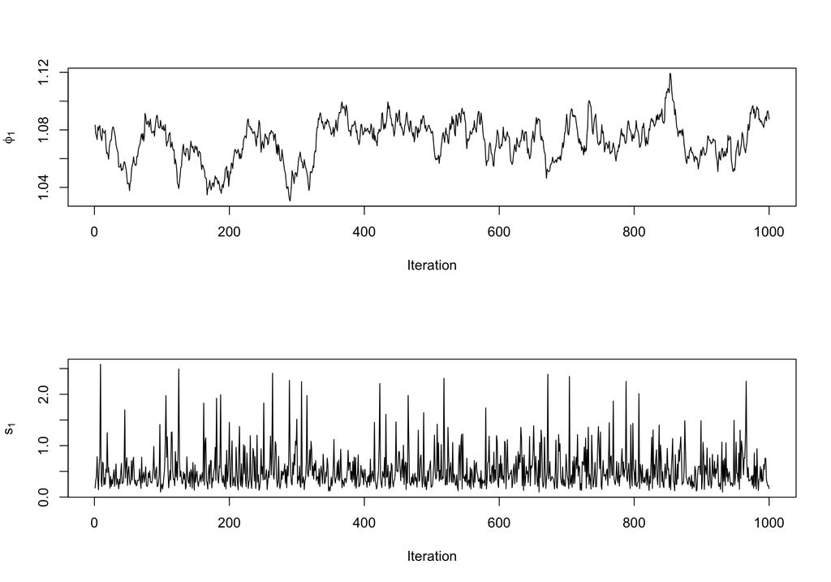

```r
par(mfrow = c(2,1))
plot(MCMC_Output, Param = "phi", Cell = 1)
plot(MCMC_Output, Param = "s", Cell = 1)
```

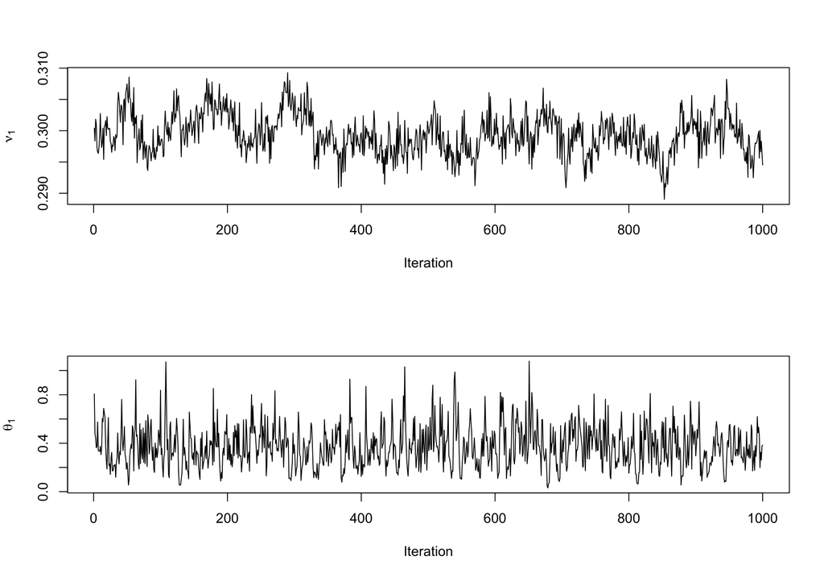

```r
par(mfrow = c(2,1))
plot(MCMC_Output, Param = "nu", Cell = 1)
plot(MCMC_Output, Param = "theta")
```

DIY: Apply other convergence diagnostics to

- Randomly selected parameters
- Average values across groups of parameters

\vspace{0.5cm}

HINT: To return the MCMC chain related to the parameter indicated by `Param` (1 column per param, 1 row per iteration) use

```r
displayChainBASiCS(MCMC_Output, Param = "mu")
```

# Post-processing of BASiCS results

## Posterior summary

The MCMC chains generated by the `BASiCS_MCMC` function contain samples from the posterior distribuion of all model parameters.

How can we summarise this information?

Some commonly used summaries are:

- Posterior means, medians, modes
- Highest Posterior Density (HPD) intervals

```r
MCMC_Summary <- Summary(MCMC_Output)
head(displaySummaryBASiCS(MCMC_Summary, Param = "mu"))
```

```
##                Mu      lower      upper
## Mrpl15  118.50366 101.549383 136.008577
## Lypla1   15.90662  12.210897  20.727531
## Tcea1    65.80454  57.783235  75.717895
## Atp6v1h  10.99437   8.824184  13.792765
## Rb1cc1    6.30325   4.136419   8.604226
## Pcmtd1   16.56348  13.387657  20.116589
```

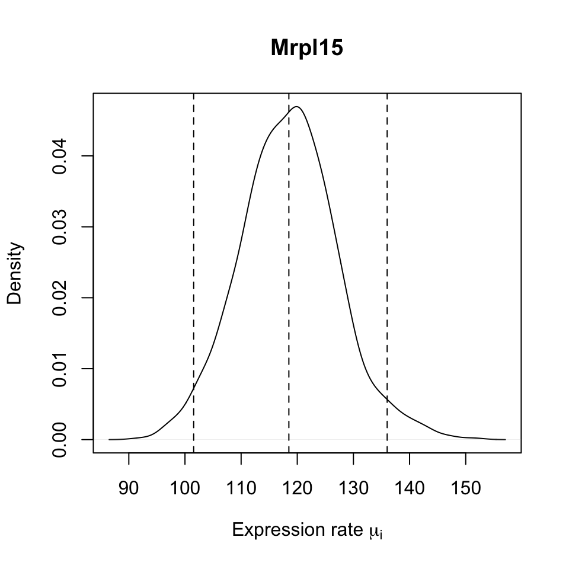

```r
plot(density(displayChainBASiCS(MCMC_Output, Param = "mu")[,1]),
  main = displayGeneNames(Data)[1],
  xlab = expression(paste("Expression rate ",mu[i])))
abline(v = displaySummaryBASiCS(MCMC_Summary, Param = "mu")[1,], lty = 2)
```

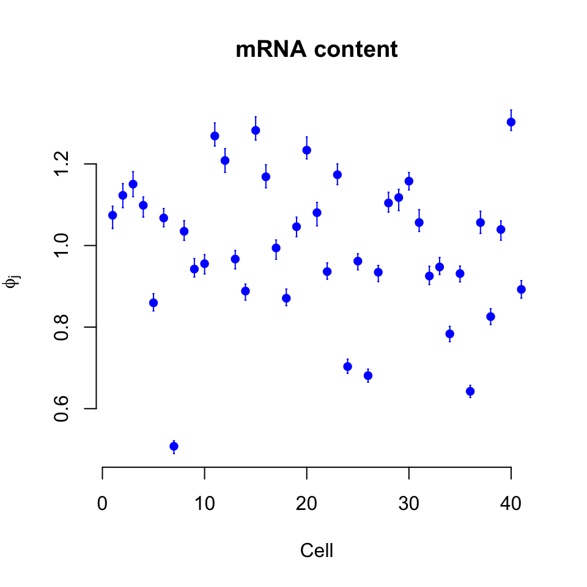

```r
plot(MCMC_Summary, Param = "phi",
  main = "mRNA content")
```

- There is some heterogeneity in the total mRNA content per cell
- Yet, this is still a very homogeneous population of cells

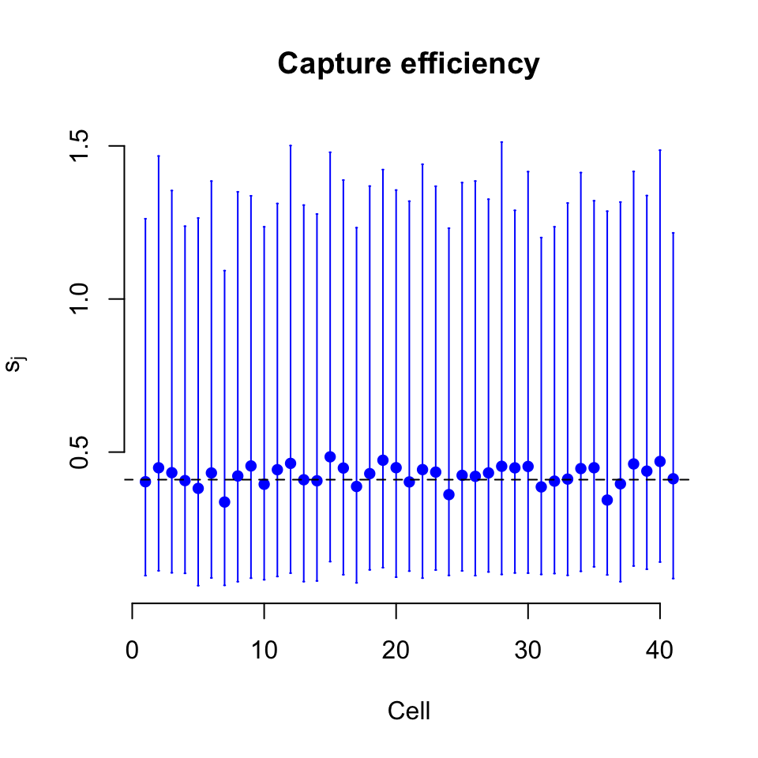

```r
plot(MCMC_Summary, Param = "s",
  main = "Capture efficiency")
abline(h = 0.41, lty = 2)
```

- No amplification biases, as expected for UMI-based counts

### Expression vs variability

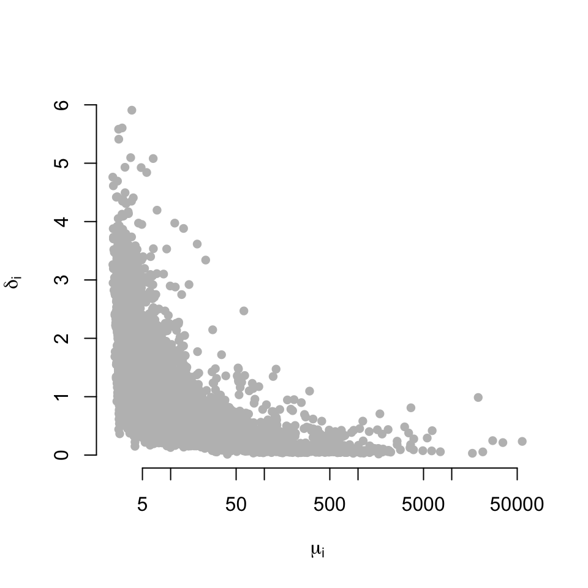

```r
plot(MCMC_Summary,
  Param = "mu", Param2 = "delta",
  log = "x", col = 8)
```

- Highly expressed genes are more stable (core celullar processes)
- More variable genes concentrated on the lower end of expression

This figure changes when analysing more heterogeneous cell populations

## Variance decomposition

BASiCS also provides a variance decomposition for the total variability of gene expression

```r
VD = BASiCS_VarianceDecomp(Data,
                        MCMC_Output)
```

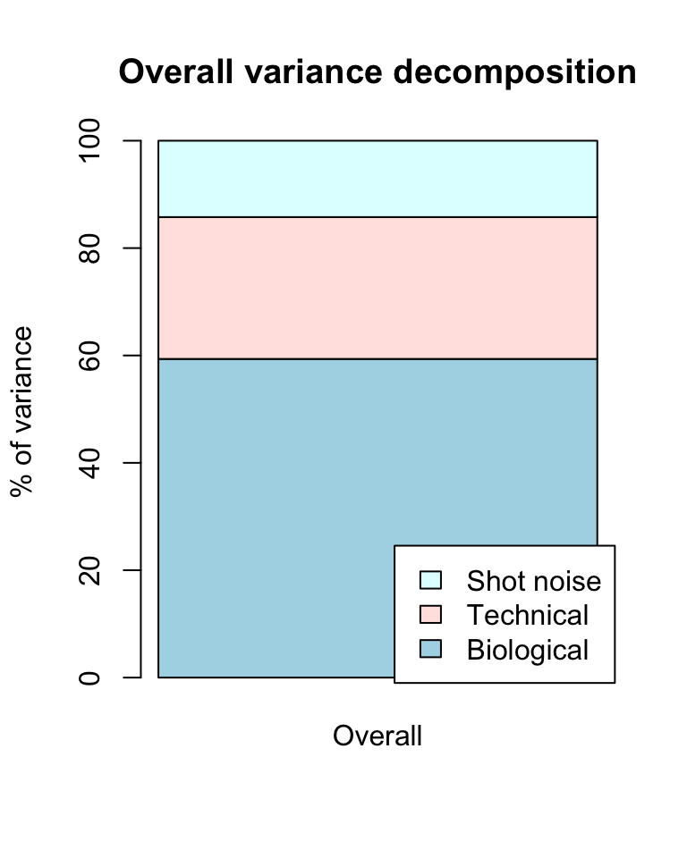

- Overall, more than 20% of the total variability is technical

We also define \begin{equation*} \sigma_i = \frac{\delta_i (\theta+1) }{[(\phi s)^* \mu_i ]^{-1} + \theta + \delta_i (\theta+1) }, \hspace{0.5cm} (\phi s)^* = \underset{j \in \{1,\ldots,n\}}{\mathrm{median}} \left\{ \phi_j s_j \right\} \end{equation*}

Similar expressions can be defined for the components related to technical variability and shot noise

```r
head(VD)
```

```
##      GeneIndex      GeneNames BioVarGlobal TechVarGlobal
## 7874      7874     r_RLTR4_Mm    0.9123013    0.06412557
## 5458      5458           Dqx1    0.9100479    0.06913547
## 7610      7610 r_IAPEY4_I-int    0.9084338    0.05973154
## 5488      5488         Ccdc48    0.9040725    0.05801302
## 4217      4217         Sprr2b    0.9033327    0.04616825
## 7310      7310       r_MT2_Mm    0.8955119    0.09325703
##      ShotNoiseGlobal
## 7874      0.02357308
## 5458      0.02081663
## 7610      0.03183469
## 5488      0.03791444
## 4217      0.05049901
## 7310      0.01123105
```

```r
tail(VD)
```

```
##      GeneIndex      GeneNames BioVarGlobal TechVarGlobal
## 5753      5753          Rps16   0.11689057     0.8776069
## 4111      4111          Naa15   0.11158450     0.8099117
## 7860      7860 r_SSU-rRNA_Hsa   0.10828025     0.8913409
## 7255      7255      r_L1_Mur2   0.10695913     0.8855819
## 2891      2891       Hsp90ab1   0.06398677     0.9322893
## 3475      3475        Mir466d   0.04305263     0.8110232
##      ShotNoiseGlobal
## 5753    0.0055025028
## 4111    0.0785038121
## 7860    0.0003788973
## 7255    0.0074589975
## 2891    0.0037239672
## 3475    0.1459241254
```

## Detection of highly and lowly variable genes

- Highly Variable Genes (HVG): for a given $\gamma_{_H}$, and $\alpha_{_H}$, BASiCS labels a gene as HVG if: \begin{equation*} \pi^H_{ i } (\gamma_{_H})= \mbox{P} \left(\sigma_{i} > {\gamma_{_H}} | \; \; \{ \text{Data} \} \right) > {\alpha_{_H}} \end{equation*}
- Lowly Variable Genes (LVG): similarly, for a given $\gamma_{_L}$, and $\alpha_{_L}$, we classify as LVG those for which: \begin{equation*} \pi^H_{ i } (\gamma_{_L})= \mbox{P} \left(\sigma_{i} < {\gamma_{_L}} | \; \; \{ \text{Data} \} \right) > {\alpha_{_L}} \end{equation*}

How to determine these thresholds?

- $\gamma_{_H}$ and $\gamma_{_L}$ have a biological meaning and therefore can be chosen by an expert
- $\alpha_{_H}$ and $\alpha_{_L}$ are evidence thresholds and can be chosen by controlling the trade-off between EFDR and EFNR.

### Highly Variable Genes

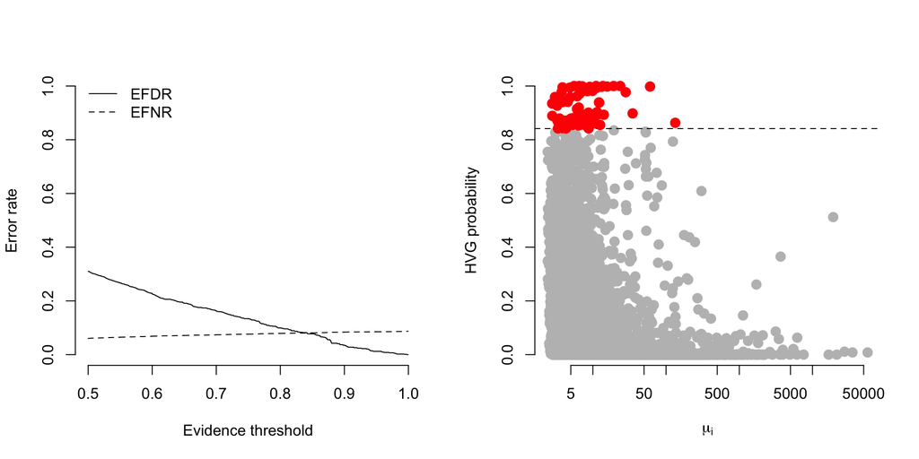

```
## 70  genes classified as highly variable using:
## - Variance contribution threshold =  79 %
## - Evidence threshold =  0.8415
## - EFDR =  8.19 %
## - EFNR =  8.04 %
```

```r
par(mfrow = c(1,2))
DetectHVG <- BASiCS_DetectHVG(Data, MCMC_Output,
                           VarThreshold = 0.79, Plot = TRUE)
```

```r
head(DetectHVG$Table)
```

```
##      GeneIndex      GeneNames        mu    delta     Sigma
## 4217      4217         Sprr2b  6.513094 5.079987 0.9033327
## 5458      5458           Dqx1 23.657981 3.340920 0.9100479
## 5488      5488         Ccdc48 11.065827 3.973877 0.9040725
## 7610      7610 r_IAPEY4_I-int 13.742015 3.882272 0.9084338
## 7682      7682      r_RLTR13A  5.554589 4.840965 0.8932325
## 7874      7874     r_RLTR4_Mm 19.215198 3.615173 0.9123013
##      Prob  HVG
## 4217    1 TRUE
## 5458    1 TRUE
## 5488    1 TRUE
## 7610    1 TRUE
## 7682    1 TRUE
## 7874    1 TRUE
```

### Lowly variable genes

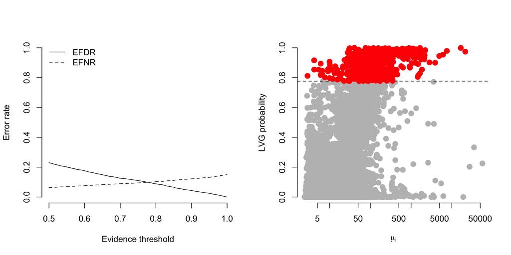

```
## 505  genes classified as lowly variable using:
## - Variance contribution threshold =  41 %
## - Evidence threshold =  0.7765
## - EFDR =  9.87 %
## - EFNR =  9.86 %
```

```r
par(mfrow = c(1,2))
DetectLVG <- BASiCS_DetectLVG(Data, MCMC_Output,
                           VarThreshold = 0.41, Plot = TRUE)
```

```r
head(DetectLVG$Table)
```

```
##      GeneIndex      GeneNames          mu      delta
## 3475      3475        Mir466d    40.33276 0.01328404
## 2891      2891       Hsp90ab1  1658.37778 0.01771576
## 4111      4111          Naa15    76.36275 0.03434140
## 7860      7860 r_SSU-rRNA_Hsa 16617.48719 0.03060549
## 3197      3197          Rpl17   119.38491 0.04280755
## 7173      7173         Rpl36a   156.77882 0.03678390
##           Sigma  Prob  LVG
## 3475 0.04305263 1.000 TRUE
## 2891 0.06398677 0.999 TRUE
## 4111 0.11158450 0.999 TRUE
## 7860 0.10828025 0.999 TRUE
## 3197 0.13835256 0.998 TRUE
## 7173 0.11902292 0.998 TRUE
```

# And beyond …

There are aspects of scRNA-seq and downstream analysis that were not covered by this tutorial

## Batch effects

The current implementation of BASiCS also allows batch-effect correction using batch-specific values of $\theta$. To use this feature, the `BASiCS_Data` object requires an additional element. For example

```r
Data = newBASiCS_Data(Counts = CountsQC,
                   Tech = TechQC,
                   SpikeInfo = SpikeInfoQC,
                   BatchInfo = c(rep(1, times = 20), rep(2, times = 21)))
```

```
## An object of class BASiCS_Data
##  Dataset contains 7941 genes (7895 biological and 46 technical) and 41 cells.
##  Elements (slots): Counts, Tech, SpikeInput, GeneNames and BatchInfo.
##  The data contains 2 batches.
##
## NOTICE: BASiCS requires a pre-filtered dataset
##     - You must remove poor quality cells before creating the BASiCS data object
##     - We recommend to pre-filter very lowly expressed transcripts before creating the object.
##       Inclusion criteria may vary for each data. For example, remove transcripts
##           - with very low total counts across of all of the samples
##           - that are only expressed in a few cells
##             (by default genes expressed in only 1 cell are not accepted)
##           - with very low total counts across the samples where the transcript is expressed
##
##  BASiCS_Filter can be used for this purpose
```

## Denoised data

You can extract **normalised and denoised** expression rates to be used for other downstream analyses. For each gene $i$ and cell $j$, these are defined as \begin{equation*} \mbox{DR}_{ij} = \mu_i \rho_{ij} \end{equation*}

Posterior estimates for these quantities can be obtained using

```r
DR = BASiCS_DenoisedRates(Data, MCMC_Output)
```

```
## [1] "This calculation requires a loop across the 1000 MCMC iterations"
## [1] "Please be patient ... "
##
## [1] "To see a progress report use PrintProgress = TRUE"
```